WEEK 2: GREEN CART LTD PROJECT Ivelina Angelova

```python
# === WEEK 2: GREEN CART LTD PROJECT ===

# ---------- BASIC SETUP ----------
import pandas as pd
import numpy as np
import matplotlib.pyplot as plt
import seaborn as sns
import os
from datetime import datetime

# Display options
pd.set_option("display.max_columns", None)
pd.set_option("display.float_format", "{:.2f}".format)
sns.set(style="whitegrid", palette="pastel")

# ---------- VERIFY WORKING DIRECTORY ----------
print("Current working directory:", os.getcwd())
print("\nFiles available:")
print(os.listdir())

# ---------- LOAD TEST ----------
try:
    sales = pd.read_csv("sales_data.csv")
    products = pd.read_csv("product_info.csv")
    customers = pd.read_csv("customer_info.csv")
    print("\n✅ All files loaded successfully!")
except FileNotFoundError:
    print("\n⚠️ Check file names and locations — file(s) not found.")
```

```
Current working directory: C:\Users\iveli

Files available:
['.anaconda', '.bash_history', '.conda', '.condarc', '.continuum', '.gitconfig', '.idlerc', '.ipynb_checkpoints', '.ipython', '.jupyter', '.matplotlib', '.ms-ad', '.python_history', '.virtual_documents', '.vscode', 'anaconda3', 'anaconda_projects', 'AppData', 'Application Data', 'Contacts', 'Cookies…

⚠️ Check file names and locations — file(s) not found.
```

```python
import pandas as pd

sales = pd.read_csv("sales_data.csv")
products = pd.read_csv("product_info.csv")
customers = pd.read_csv("customer_info.csv")

print("✅ All files loaded successfully!")
print("Sales shape:", sales.shape)
print("Products shape:", products.shape)
print("Customers shape:", customers.shape)
```

```
✅ All files loaded successfully!
Sales shape: (3000, 10)
Products shape: (30, 6)
Customers shape: (500, 6)
```

```python
import pandas as pd
import os

# Option 1: Check if files exist before loading
try:
    # You can specify the full path to your files if they're in a different directory
    # For example: sales = pd.read_csv("/path/to/your/sales_data.csv")
    sales = pd.read_csv("r:/Users/iveli/OneDrive/Desktop/Week2_GreenCart_Projectsales_data.csv")
    products = pd.read_csv("product_info.csv")
    customers = pd.read_csv("customer_info.csv")

    print("✅ All files loaded successfully!")
    print("Sales shape:", sales.shape)
    print("Products shape:", products.shape)
    print("Customers shape:", customers.shape)
except FileNotFoundError as e:
    print(f"Error: {e}")
    print(f"Current working directory: {os.getcwd()}")
    print("Please make sure the CSV files exist in this directory or provide the full path.")
```

```
Error: [Errno 2] No such file or directory: 'r:/Users/iveli/OneDrive/Desktop/Week2_GreenCart_Projectsales_data.csv'
Current working directory: C:\Users\iveli
Please make sure the CSV files exist in this directory or provide the full path.
```

```python
import os

# FIXED PATH — add missing backslash
os.chdir(r"C:\Users\iveli\OneDrive\Desktop\Week2_GreenCart_Project")

# Confirm
print(" Working directory changed to:", os.getcwd())
print("\nFiles in this folder:")
print(os.listdir())
```

```
 Working directory changed to: C:\Users\iveli\OneDrive\Desktop\Week2_GreenCart_Project

Files in this folder:
['customer_info.csv', 'product_info.csv', 'Project Coversheet.docx', 'sales_data.csv', 'Week 2 - Project Brief - Sales and Customer Behaviour Insights - Green Cart Ltd.pdf']
```

```python
import pandas as pd

sales = pd.read_csv("sales_data.csv")
products = pd.read_csv("product_info.csv")
customers = pd.read_csv("customer_info.csv")

print(" All files loaded successfully!")
print("Sales shape:", sales.shape)
print("Products shape:", products.shape)
print("Customers shape:", customers.shape)
```

```
 All files loaded successfully!
Sales shape: (3000, 10)
Products shape: (30, 6)
Customers shape: (500, 6)
```

```python
for file in os.listdir():
    if file.endswith(".csv"):
        print("Found CSV:", file)
```

```
Found CSV: customer_info.csv
Found CSV: product_info.csv
Found CSV: sales_data.csv
```

# 🧮 Step 1: Load and Inspect Data

### 🎯 Goal

The purpose of this step is to import, inspect, and understand the three datasets provided by Green Cart Ltd.:

- **sales_data.csv**
- **product_info.csv**
- **customer_info.csv**

Before cleaning or merging, we must confirm:

- The structure and size of each dataset
- Column names and data types
- Missing values, duplicate records, and inconsistencies
- The validity of key fields such as dates and numeric values

### 🧭 Actions

1. Load each CSV file into a separate Pandas DataFrame.
2. Standardise all column names to *snake_case* for consistency.
3. Use `.info()`, `.shape`, and `.head()` to preview the structure.
4. Identify missing values and duplicate IDs.
5. Check for inconsistent category labels (e.g., region, loyalty_tier).
6. Preview date columns to detect invalid formats.
7. Validate numeric columns to ensure non-negative and realistic values.
8. Export small “audit” CSVs (missing counts, numeric checks) for screenshots or the report appendix.

### 💡 Why This Step Matters

Conducting an initial audit ensures data reliability.  
By identifying problems early—such as blank regions, mis-cased labels, or invalid dates—we can plan targeted cleaning steps in Step 2.  
This stage forms the foundation for trustworthy analysis later in the project.

# 🧮 Step 1: Load and Inspect Data

### 🎯 Goal

The purpose of this step is to import, inspect, and understand the three datasets provided by Green Cart Ltd.:

- **sales_data.csv**
- **product_info.csv**
- **customer_info.csv**

Before cleaning or merging, we must confirm:

- The structure and size of each dataset
- Column names and data types
- Missing values, duplicate records, and inconsistencies
- The validity of key fields such as dates and numeric values

### 🧭 Actions

1. Load each CSV file into a separate Pandas DataFrame.
2. Standardise all column names to *snake_case* for consistency.
3. Use `.info()`, `.shape`, and `.head()` to preview the structure.
4. Identify missing values and duplicate IDs.
5. Check for inconsistent category labels (e.g., region, loyalty_tier).
6. Preview date columns to detect invalid formats.
7. Validate numeric columns to ensure non-negative and realistic values.
8. Export small “audit” CSVs (missing counts, numeric checks) for screenshots or the report appendix.

### 💡 Why This Step Matters

Conducting an initial audit ensures data reliability.  
By identifying problems early-such as blank regions, mis-cased labels, or invalid dates-we can plan targeted cleaning steps in Step 2.  
This stage forms the foundation for trustworthy analysis later in the project.

```python
# === STEP 1: LOAD & INSPECT (AUDIT ONLY — NON-DESTRUCTIVE) ===
import pandas as pd
import numpy as np

# Expect: you already loaded these in memory earlier
# sales, products, customers

def to_snake(df):
    df2 = df.copy()
    df2.columns = (df2.columns
                   .str.strip()
                   .str.replace(r"\s+", "_", regex=True)
                   .str.lower())
    return df2

def audit_missing(df, name):
    miss = df.isna().sum().to_frame("missing")
    miss["pct"] = (miss["missing"] / len(df) * 100).round(2)
    miss.insert(0, "column", miss.index)
    miss = miss.reset_index(drop=True)
    print(f"\n--- Missing audit: {name} ---\n", miss.sort_values("missing", ascending=False).head(20))
    return miss

def preview_categories(df, cols):
    for c in cols:
        if c in df.columns:
            vals = df[c].astype("string").str.strip()
            print(f"\n{c}: unique sample ->", sorted(vals.dropna().unique().tolist())[:12])

def date_preview(df, col, dayfirst=True):
    if col not in df.columns:
        return {"col": col, "present": False}
    parsed = pd.to_datetime(df[col], errors="coerce", dayfirst=dayfirst)
    invalid = parsed.isna().sum()
    return {"col": col, "present": True, "rows": len(df),
            "invalid_dates": int(invalid),
            "invalid_pct": round(invalid/len(df)*100,2)}

def numeric_checks(df, rules):
    findings = []
    for col, rule in rules.items():
        if col not in df.columns:
            findings.append((col, "missing_col", 0))
            continue
        s = pd.to_numeric(df[col], errors="coerce")
        if rule == "non_negative":
            bad = (s < 0).sum()
            findings.append((col, "negatives", int(bad)))
        elif rule == "fraction_0_1":
            bad = ((s < 0) | (s > 1)).sum()
            findings.append((col, "out_of_[0,1]", int(bad)))
    return pd.DataFrame(findings, columns=["column","issue","count"])

# 1. Standardise column names (work copies)
sales_df    = to_snake(sales)
products_df = to_snake(products)
customers_df= to_snake(customers)

print("=== Shapes ===")
print("sales:", sales_df.shape, "| products:", products_df.shape, "| customers:", customers_df.shape)

print("\n=== Dtypes (sales) ===");    print(sales_df.dtypes)
print("\n=== Dtypes (products) ==="); print(products_df.dtypes)
print("\n=== Dtypes (customers) ===");print(customers_df.dtypes)

print("\n=== Head previews ===")
print("sales:\n", sales_df.head(3))
print("\nproducts:\n", products_df.head(3))
print("\ncustomers:\n", customers_df.head(3))

# 2️. Missing audits
miss_sales    = audit_missing(sales_df,    "sales")
miss_products = audit_missing(products_df, "products")
miss_customers= audit_missing(customers_df,"customers")

# 3️. Duplicate keys (by expected IDs if present)
dup_sales = sales_df.duplicated(subset=[c for c in ["order_id"] if c in sales_df.columns]).sum()
dup_products = products_df.duplicated(subset=[c for c in ["product_id"] if c in products_df.columns]).sum()
dup_customers = customers_df.duplicated(subset=[c for c in ["customer_id"] if c in customers_df.columns]).sum()
print(f"\n--- Duplicate keys ---\nsales(order_id): {dup_sales}\nproducts(product_id): {dup_products}\ncustomers(customer_id): {dup_customers}")

# 4️. Category previews for inconsistent casing/labels
preview_categories(sales_df,    ["delivery_status","payment_method","region"])
preview_categories(products_df, ["category","supplier_code"])
preview_categories(customers_df,["gender","region","loyalty_tier"])

# 5️. Date sanity (parse-preview only)
date_checks = []
date_checks.append(date_preview(sales_df, "order_date"))
date_checks.append(date_preview(products_df, "launch_date"))
date_checks.append(date_preview(customers_df, "signup_date"))
print("\n--- Date parse preview ---")
for d in date_checks:
    print(d)

# 6️. Numeric sanity
num_rules = {
    "quantity": "non_negative",
    "unit_price": "non_negative",
    "discount_applied": "fraction_0_1"
}
num_sales = numeric_checks(sales_df, num_rules)
print("\n--- Numeric sanity (sales) ---\n", num_sales)

# 7️. Optional: export audits for screenshots
miss_sales.to_csv("w2_audit_missing_sales.csv", index=False)
miss_products.to_csv("w2_audit_missing_products.csv", index=False)
miss_customers.to_csv("w2_audit_missing_customers.csv", index=False)
num_sales.to_csv("w2_audit_numeric_sales.csv", index=False)
print("\n📁 Saved audit CSVs: w2_audit_missing_*.csv, w2_audit_numeric_sales.csv")
```

```
=== Shapes ===
sales: (3000, 10) | products: (30, 6) | customers: (500, 6)

=== Dtypes (sales) ===
order_id             object
customer_id          object
product_id           object
quantity             object
unit_price          float64
order_date           object
delivery_status      object
payment_method       object
region               object
discount_applied    float64
dtype: object

=== Dtypes (products) ===
product_id        object
product_name      object
category          object
launch_date       object
base_price       float64
supplier_code     object
dtype: object

=== Dtypes (customers) ===
customer_id     object
email           object
signup_date     object
gender          object
region          object
loyalty_tier    object
dtype: object

=== Head previews ===
sales:
   order_id customer_id product_id quantity  unit_price  order_date  \
0  O966977      C00397      P0022        3       39.25  06-07-2025
1  O696648      C00236      P0023        5       18.92  06-07-2025
2  O202644      C00492      P0011        1       29.68  07-07-2025
```

[output cut: 64 more lines]

```
delivery_status: unique sample -> ['Cancelled', 'DELAYED', 'Delayed', 'Delivered', 'delivered', 'delrd', 'delyd']

payment_method: unique sample -> ['Bank Transfer', 'Credit Card', 'PayPal', 'bank transfr', 'credit card']

region: unique sample -> ['Central', 'East', 'North', 'South', 'West', 'nrth']

category: unique sample -> ['Cleaning', 'Kitchen', 'Outdoors', 'Personal Care', 'Storage']

supplier_code: unique sample -> ['S127', 'S321', 'S339', 'S379', 'S424', 'S455', 'S466', 'S481', 'S492', 'S503', 'S558', 'S559']

gender: unique sample -> ['FEMALE', 'Female', 'Male', 'Other', 'femle', 'male']

region: unique sample -> ['Central', 'East', 'North', 'South', 'West']

loyalty_tier: unique sample -> ['GOLD', 'Silver', 'brnze', 'bronze', 'gld', 'gold', 'sllver']
```

```
--- Date parse preview ---
{'col': 'order_date', 'present': True, 'rows': 3000, 'invalid_dates': 2, 'invalid_pct': 0.07}
{'col': 'launch_date', 'present': True, 'rows': 30, 'invalid_dates': 0, 'invalid_pct': 0.0}
{'col': 'signup_date', 'present': True, 'rows': 500, 'invalid_dates': 4, 'invalid_pct': 0.8}

--- Numeric sanity (sales) ---
              column         issue  count
0          quantity     negatives      0
1        unit_price     negatives      0
2  discount_applied  out_of_[0,1]      0

📁 Saved audit CSVs: w2_audit_missing_*.csv, w2_audit_numeric_sales.csv
```

# 🧹 Step 2: Clean Each Dataset Individually

### 🎯 Goal

Prepare all three datasets (`sales_data`, `product_info`, and `customer_info`) for merging by ensuring accuracy, consistency, and completeness.

### 🧭 Actions

For each dataset:

### 💡 Why This Step Matters

Data cleaning ensures the merged dataset is reliable for feature engineering and analysis.  
Standardising formats prevents merge mismatches and ensures accurate grouping and aggregation in later steps.

```python
# === STEP 2: CLEAN EACH DATASET ===
import numpy as np
import pandas as pd

# Work on copies from Step 1
sales_clean    = sales_df.copy()
products_clean = products_df.copy()
customers_clean= customers_df.copy()

# ---------- Helper: text normaliser ----------
def norm_text(series):
    return (series.astype("string")
                  .str.strip()
                  .str.replace(r"\s+", " ", regex=True)
                  .str.title())

# ---------- 1️⃣ SALES DATA CLEANING ----------
print("\n=== Cleaning: SALES DATA ===")
if "delivery_status" in sales_clean.columns:
    sales_clean["delivery_status"] = norm_text(sales_clean["delivery_status"])
if "payment_method" in sales_clean.columns:
    sales_clean["payment_method"] = norm_text(sales_clean["payment_method"])
if "region" in sales_clean.columns:
    sales_clean["region"] = norm_text(sales_clean["region"])

# Convert order_date
sales_clean["order_date"] = pd.to_datetime(sales_clean["order_date"], errors="coerce", dayfirst=True)

# Replace missing numeric fields
for col in ["quantity","unit_price","discount_applied"]:
    if col in sales_clean.columns:
        sales_clean[col] = pd.to_numeric(sales_clean[col], errors="coerce")
        if col == "discount_applied":
            sales_clean[col] = sales_clean[col].fillna(0.0)
        else:
            sales_clean[col] = sales_clean[col].fillna(0)

# Drop invalid/blank key rows
if "order_id" in sales_clean.columns:
    before = len(sales_clean)
    sales_clean = sales_clean.dropna(subset=["order_id","customer_id","product_id"])
    print(f"Rows dropped (missing IDs): {before - len(sales_clean)}")

# Remove duplicates
sales_clean = sales_clean.drop_duplicates(subset="order_id", keep="first")

# Validate numeric columns
num_cols = ["quantity","unit_price","discount_applied"]
for col in num_cols:
    if col in sales_clean.columns:
        negatives = (sales_clean[col] < 0).sum()
        if negatives > 0:
            print(f"{col}: {negatives} negative values corrected to 0")
            sales_clean.loc[sales_clean[col] < 0, col] = 0

# ---------- 2️⃣ PRODUCT DATA CLEANING ----------
print("\n=== Cleaning: PRODUCT DATA ===")
for col in ["category","supplier_code"]:
    if col in products_clean.columns:
        products_clean[col] = norm_text(products_clean[col])

products_clean["launch_date"] = pd.to_datetime(products_clean["launch_date"], errors="coerce", dayfirst=True)

# Drop invalid product_id
if "product_id" in products_clean.columns:
    before = len(products_clean)
    products_clean = products_clean.dropna(subset=["product_id"])
    products_clean = products_clean.drop_duplicates(subset="product_id", keep="first")
    print(f"Rows dropped (invalid product_id): {before - len(products_clean)}")

# Fill missing base_price with median if available
if "base_price" in products_clean.columns:
    median_price = products_clean["base_price"].median()
    products_clean["base_price"] = products_clean["base_price"].fillna(median_price)

# ---------- 3️⃣ CUSTOMER DATA CLEANING ----------
print("\n=== Cleaning: CUSTOMER DATA ===")
for col in ["gender","region","loyalty_tier"]:
    if col in customers_clean.columns:
        customers_clean[col] = norm_text(customers_clean[col])

customers_clean["signup_date"] = pd.to_datetime(customers_clean["signup_date"], errors="coerce", dayfirst=True)

# Drop invalid customer_id
if "customer_id" in customers_clean.columns:
    before = len(customers_clean)
    customers_clean = customers_clean.dropna(subset=["customer_id"])
    customers_clean = customers_clean.drop_duplicates(subset="customer_id", keep="first")
    print(f"Rows dropped (invalid customer_id): {before - len(customers_clean)}")

# Fill missing text fields
fill_values = {"region":"Unknown","gender":"Unspecified","loyalty_tier":"Unknown"}
customers_clean = customers_clean.fillna(value=fill_values)

# ---------- 4️⃣ POST-CLEAN CHECKS ----------
print("\n=== AFTER CLEANING SNAPSHOT ===")
print("sales:", sales_clean.shape)
print("products:", products_clean.shape)
print("customers:", customers_clean.shape)

print("\nRemaining missing values (top 10 cols):")
print(sales_clean.isna().sum().sort_values(ascending=False).head(10))
print(products_clean.isna().sum().sort_values(ascending=False).head(10))
print(customers_clean.isna().sum().sort_values(ascending=False).head(10))

# ---------- 5️⃣ SAVE CLEAN VERSIONS ----------
sales_clean.to_csv("sales_data_clean.csv", index=False)
products_clean.to_csv("product_info_clean.csv", index=False)
customers_clean.to_csv("customer_info_clean.csv", index=False)
print("\n✅ Cleaned files saved: sales_data_clean.csv, product_info_clean.csv, customer_info_clean.csv")
```

```
=== Cleaning: SALES DATA ===
Rows dropped (missing IDs): 8

=== Cleaning: PRODUCT DATA ===
Rows dropped (invalid product_id): 0

=== Cleaning: CUSTOMER DATA ===
```

```
Rows dropped (invalid customer_id): 3

=== AFTER CLEANING SNAPSHOT ===
sales: (2990, 10)
products: (30, 6)
customers: (497, 6)

Remaining missing values (top 10 cols):
delivery_status     3
payment_method      3
order_date          2
order_id            0
customer_id         0
product_id          0
quantity            0
unit_price          0
region              0
discount_applied    0
dtype: int64
product_id       0
product_name     0
category         0
launch_date      0
base_price       0
supplier_code    0
dtype: int64
email           6
signup_date     4
customer_id     0
gender          0
region          0
loyalty_tier    0
dtype: int64

✅ Cleaned files saved: sales_data_clean.csv, product_info_clean.csv, customer_info_clean.csv
```

Where applicable, SQL queries (via pandasql) will be used to validate joins and generate summary tables. This approach provides transparency and replicates real-world data analysis workflows.

```python
# Install pandasql if not installed
!pip install -q pandasql

# Import it
from pandasql import sqldf

# Define SQL query helper
pysqldf = lambda q: sqldf(q, globals())
```

```python
q = """
SELECT region, COUNT(order_id) AS orders,
       SUM(quantity * unit_price * (1 - discount_applied)) AS total_revenue
FROM sales_clean
GROUP BY region
ORDER BY total_revenue DESC
"""
region_revenue = pysqldf(q)
region_revenue.head()
```

|  | region | orders | total_revenue |
| --- | --- | --- | --- |
| 0 | South | 595 | 49560.57 |
| 1 | East | 601 | 47842.84 |
| 2 | West | 588 | 47729.82 |
| 3 | Central | 602 | 47444.29 |
| 4 | North | 603 | 46758.98 |

```python
# Load clean datasets
sales = pd.read_csv("sales_data_clean.csv")
products = pd.read_csv("product_info_clean.csv")
customers = pd.read_csv("customer_info_clean.csv")

# Register them for SQL
q = """
SELECT s.*, p.category, p.base_price, p.launch_date,
       c.email, c.signup_date, c.gender, c.loyalty_tier, c.region AS customer_region
FROM sales AS s
LEFT JOIN products AS p ON s.product_id = p.product_id
LEFT JOIN customers AS c ON s.customer_id = c.customer_id
"""
merged_df = pysqldf(q)
merged_df.head()
```

|  | order_id | customer_id | product_id | quantity | unit_price | order_date | delivery_status | payment_method | region | discount_applied | category | base_price | launch_date | email | signup_date | gender | loyalty_tier | customer_region |
| --- | --- | --- | --- | --- | --- | --- | --- | --- | --- | --- | --- | --- | --- | --- | --- | --- | --- | --- |
| 0 | O966977 | C00397 | P0022 | 3.00 | 39.25 | 2025-07-06 | Delivered | Paypal | Central | 0.00 | Cleaning | 19.77 | 2024-10-04 | jacquelinemartin@mills-logan.com | 2024-09-08 | Female | Silver | North |
| 1 | O696648 | C00236 | P0023 | 5.00 | 18.92 | 2025-07-06 | Delayed | Credit Card | North | 0.00 | Outdoors | 36.04 | 2025-01-18 | georgeweber@morgan.com | 2024-08-06 | Other | Gold | North |
| 2 | O202644 | C00492 | P0011 | 1.00 | 29.68 | 2025-07-07 | Delivered | Bank Transfer | North | 0.15 | Kitchen | 11.08 | 2025-03-25 | lcook@walters-smith.com | 2024-09-25 | Male | Gold | Central |
| 3 | O501803 | C00031 | P0003 | 1.00 | 32.76 | 2025-07-08 | Cancelled | Credit Card | Central | 0.20 | Cleaning | 7.92 | 2024-07-15 | smoore@gmail.com | 2024-07-28 | Femle | Gold | Central |
| 4 | O322242 | C00495 | P0016 | 1.00 | 47.62 | 2025-07-08 | Delayed | Credit Card | West | 0.20 | Cleaning | 26.71 | 2025-02-20 | mcclainkatherine@hotmail.com | 2024-09-18 | Male | Gold | Central |

```python
q = """
SELECT STRFTIME('%W', order_date) AS order_week,
       region,
       ROUND(SUM(quantity * unit_price * (1 - discount_applied)), 2) AS weekly_revenue
FROM merged_df
GROUP BY order_week, region
ORDER BY order_week, region
"""
weekly_revenue_sql = pysqldf(q)
weekly_revenue_sql.head()
```

|  | order_week | region | weekly_revenue |
| --- | --- | --- | --- |
| 0 | None | Central | 90.86 |
| 1 | None | East | 43.38 |
| 2 | 13 | Central | 68.76 |
| 3 | 13 | East | 70.12 |
| 4 | 13 | North | 195.18 |

# 🔗 Step 3: Merge the Datasets

### 🎯 Goal

Combine the cleaned datasets into one master DataFrame that includes sales, product, and customer information.

### 🧭 Actions

1. Merge `sales_clean` with `products_clean` on **product_id**.
2. Merge the result with `customers_clean` on **customer_id**.
3. Use `how='left'` to preserve all sales transactions (even if product or customer data is missing).
4. Verify the merge by checking row counts, nulls introduced, and unique key integrity.
5. Optionally, cross-check results using SQL queries for validation.

### 💡 Why This Step Matters

Merging datasets allows us to connect customer demographics and product attributes to each sale.  
It’s the foundation for feature engineering and generating business insights across categories, loyalty tiers, and regions.

```python
sales_clean = pd.read_csv("sales_data_clean.csv")
products_clean = pd.read_csv("product_info_clean.csv")
customers_clean = pd.read_csv("customer_info_clean.csv")
```

```python
# === STEP 3: MERGE THE DATASETS ===
import pandas as pd
from pandasql import sqldf
pysqldf = lambda q: sqldf(q, globals())

# ---------- 1️ Merge using Pandas ----------
merged_df = (
    sales_clean
    .merge(products_clean, on="product_id", how="left", suffixes=("_sale", "_product"))
    .merge(customers_clean, on="customer_id", how="left", suffixes=("", "_cust"))
)

print("✅ Merge complete.")
print("Merged shape:", merged_df.shape)
print("\nColumns:", merged_df.columns.tolist()[:12], "...")

# Quick validation
print("\nNull counts after merge (top 10):")
print(merged_df.isna().sum().sort_values(ascending=False).head(10))

print("\nUnique order IDs:", merged_df["order_id"].nunique())
print("Duplicate order IDs:", merged_df.duplicated(subset="order_id").sum())

# ---------- 2️ SQL cross-check for join integrity ----------
q = """
SELECT
    COUNT(DISTINCT s.order_id) AS total_sales_orders,
    COUNT(DISTINCT p.product_id) AS total_products,
    COUNT(DISTINCT c.customer_id) AS total_customers,
    SUM(CASE WHEN p.product_id IS NULL THEN 1 ELSE 0 END) AS missing_product_links,
    SUM(CASE WHEN c.customer_id IS NULL THEN 1 ELSE 0 END) AS missing_customer_links
FROM sales_clean AS s
LEFT JOIN products_clean AS p ON s.product_id = p.product_id
LEFT JOIN customers_clean AS c ON s.customer_id = c.customer_id
"""
validation = pysqldf(q)
print("\n🔍 SQL Validation Summary:")
print(validation)

# ---------- 3️ Save merged version ----------
merged_df.to_csv("merged_sales_data.csv", index=False)
print("\n📁 Saved merged dataset as merged_sales_data.csv")

# Preview
merged_df.head(5)
```

```
✅ Merge complete.
Merged shape: (2990, 20)

Columns: ['order_id', 'customer_id', 'product_id', 'quantity', 'unit_price', 'order_date', 'delivery_status', 'payment_method', 'region', 'discount_applied', 'product_name', 'category'] ...

Null counts after merge (top 10):
email              55
signup_date        52
loyalty_tier       24
region_cust        24
gender             24
delivery_status     3
payment_method      3
order_date          2
launch_date         0
supplier_code       0
dtype: int64

Unique order IDs: 2990
Duplicate order IDs: 0

🔍 SQL Validation Summary:
   total_sales_orders  total_products  total_customers  missing_product_links  \
0                2990              30              496                      0

   missing_customer_links
0                      24

📁 Saved merged dataset as merged_sales_data.csv
```

|  | order_id | customer_id | product_id | quantity | unit_price | order_date | delivery_status | payment_method | region | discount_applied | product_name | category | launch_date | base_price | supplier_code | email | signup_date | gender | region_cust | loyalty_tier |
| --- | --- | --- | --- | --- | --- | --- | --- | --- | --- | --- | --- | --- | --- | --- | --- | --- | --- | --- | --- | --- |
| 0 | O966977 | C00397 | P0022 | 3.00 | 39.25 | 2025-07-06 | Delivered | Paypal | Central | 0.00 | Cleaning Product 86 | Cleaning | 2024-10-04 | 19.77 | S924 | jacquelinemartin@mills-logan.com | 2024-09-08 | Female | North | Silver |
| 1 | O696648 | C00236 | P0023 | 5.00 | 18.92 | 2025-07-06 | Delayed | Credit Card | North | 0.00 | Outdoors Product 32 | Outdoors | 2025-01-18 | 36.04 | S907 | georgeweber@morgan.com | 2024-08-06 | Other | North | Gold |
| 2 | O202644 | C00492 | P0011 | 1.00 | 29.68 | 2025-07-07 | Delivered | Bank Transfer | North | 0.15 | Kitchen Product 53 | Kitchen | 2025-03-25 | 11.08 | S645 | lcook@walters-smith.com | 2024-09-25 | Male | Central | Gold |
| 3 | O501803 | C00031 | P0003 | 1.00 | 32.76 | 2025-07-08 | Cancelled | Credit Card | Central | 0.20 | Cleaning Product 85 | Cleaning | 2024-07-15 | 7.92 | S745 | smoore@gmail.com | 2024-07-28 | Femle | Central | Gold |
| 4 | O322242 | C00495 | P0016 | 1.00 | 47.62 | 2025-07-08 | Delayed | Credit Card | West | 0.20 | Cleaning Product 53 | Cleaning | 2025-02-20 | 26.71 | S715 | mcclainkatherine@hotmail.com | 2024-09-18 | Male | Central | Gold |

# ⚙️ Step 4: Feature Engineering

### 🎯 Goal

Enhance the merged dataset with new analytical features that reveal business insights and prepare the data for visualisation.

### 🧭 Actions

The following new columns are created:

1. **revenue** – total revenue per transaction  
   `revenue = quantity * unit_price * (1 - discount_applied)`
2. **order_week** – ISO week number extracted from `order_date`
3. **price_band** – categorical price segmentation
   - *Low*: < £15
   - *Medium*: £15–£30
   - *High*: > £30
4. **days_to_order** – number of days between `launch_date` (product) and `order_date` (sale)
5. **email_domain** – extracted domain name from customer email (e.g., `gmail.com`)
6. **is_late** – boolean flag if `delivery_status` = “Delayed”

### 💡 Why This Step Matters

Feature engineering translates raw columns into business-relevant indicators.  
These features help identify which products and customers drive performance, how time affects orders, and where delays or discounts influence revenue.

```python
# === STEP 4: FEATURE ENGINEERING ===
import numpy as np
import pandas as pd

# Ensure we’re using the merged dataset
merged_df = pd.read_csv("merged_sales_data.csv")

print("Starting feature engineering on merged dataset of shape:", merged_df.shape)

# ---------- 1️ Revenue ----------
merged_df["revenue"] = merged_df["quantity"] * merged_df["unit_price"] * (1 - merged_df["discount_applied"])

# ---------- 2️ Order Week ----------
merged_df["order_date"] = pd.to_datetime(merged_df["order_date"], errors="coerce")
merged_df["order_week"] = merged_df["order_date"].dt.isocalendar().week

# ---------- 3️ Price Band ----------
merged_df["price_band"] = pd.cut(
    merged_df["unit_price"],
    bins=[0, 15, 30, np.inf],
    labels=["Low", "Medium", "High"]
)

# ---------- 4️ Days to Order ----------
merged_df["launch_date"] = pd.to_datetime(merged_df["launch_date"], errors="coerce")
merged_df["days_to_order"] = (merged_df["order_date"] - merged_df["launch_date"]).dt.days

# ---------- 5️ Email Domain ----------
if "email" in merged_df.columns:
    merged_df["email_domain"] = merged_df["email"].astype(str).str.extract(r'@([\w\.-]+)')

# ---------- 6️ Is Late ----------
if "delivery_status" in merged_df.columns:
    merged_df["delivery_status"] = merged_df["delivery_status"].astype(str).str.title().str.strip()
    merged_df["is_late"] = merged_df["delivery_status"] == "Delayed"

# ---------- 7️ Post-creation check ----------
print("\n=== Feature Summary ===")
print(merged_df[["revenue", "order_week", "price_band", "days_to_order", "email_domain", "is_late"]].head())

print("\nMissing values in new features:")
print(merged_df[["revenue", "order_week", "price_band", "days_to_order"]].isna().sum())

# ---------- 8️ Save enhanced dataset ----------
merged_df.to_csv("merged_sales_data_features.csv", index=False)
print("\n✅ Saved enhanced dataset as merged_sales_data_features.csv")
```

```
Starting feature engineering on merged dataset of shape: (2990, 20)

=== Feature Summary ===
   revenue  order_week price_band  days_to_order       email_domain  is_late
0   117.75          27       High         275.00    mills-logan.com    False
1    94.60          27     Medium         169.00         morgan.com     True
2    25.23          28     Medium         104.00  walters-smith.com    False
3    26.21          28       High         358.00          gmail.com    False
4    38.10          28       High         138.00        hotmail.com     True

Missing values in new features:
revenue          0
order_week       2
price_band       1
days_to_order    2
dtype: int64

✅ Saved enhanced dataset as merged_sales_data_features.csv
```

# 📊 Step 5: Create Summary Tables

### 🎯 Goal

Generate concise analytical tables that reveal patterns in sales, customer behaviour, and delivery performance.  
These summaries form the foundation for the visualisations and business answers in later steps.

### 🧭 Actions

Using `groupby()`, `agg()`, and `pivot_table()`, the following summaries will be created:

1. **Weekly Revenue Trends by Region**
   - Total revenue and number of orders per week and region.
2. **Product Category Performance**
   - Total revenue, total quantity sold, and average discount by category.
3. **Customer Behaviour by Loyalty Tier and Signup Month**
   - Revenue, average discount, and order count by tier and month.
4. **Delivery Performance by Region and Price Band**
   - Count of delayed vs delivered orders by region and price band.
5. **Preferred Payment Methods by Loyalty Tier**
   - Payment preferences by customer segment.

### 💡 Why This Step Matters

Summary tables simplify the complexity of thousands of transactions into digestible business insights.  
They help identify which categories and regions perform best, which customers generate more value, and where operational improvements are needed.

```python
# === STEP 5: CREATE SUMMARY TABLES ===
import pandas as pd

# Load enhanced dataset
merged_df = pd.read_csv("merged_sales_data_features.csv")

print("Dataset loaded for summary creation. Shape:", merged_df.shape)

# ---------- 1️ Weekly Revenue Trends by Region ----------
weekly_revenue = (
    merged_df.groupby(["order_week", "region"], as_index=False)
    .agg(total_revenue=("revenue", "sum"), orders=("order_id", "count"))
    .sort_values(["order_week", "region"])
)

print("\n=== Weekly Revenue by Region (sample) ===")
print(weekly_revenue.head())

# ---------- 2️ Product Category Performance ----------
category_perf = (
    merged_df.groupby("category", as_index=False)
    .agg(total_revenue=("revenue", "sum"),
         total_quantity=("quantity", "sum"),
         avg_discount=("discount_applied", "mean"))
    .sort_values("total_revenue", ascending=False)
)

print("\n=== Product Category Performance (sample) ===")
print(category_perf.head())

# ---------- 3️ Customer Behaviour by Loyalty Tier and Signup Month ----------
merged_df["signup_date"] = pd.to_datetime(merged_df["signup_date"], errors="coerce")
merged_df["signup_month"] = merged_df["signup_date"].dt.month_name()

loyalty_behaviour = (
    merged_df.groupby(["loyalty_tier", "signup_month"], as_index=False)
    .agg(revenue=("revenue", "sum"),
         avg_discount=("discount_applied", "mean"),
         order_count=("order_id", "count"))
    .sort_values("revenue", ascending=False)
)

print("\n=== Customer Behaviour by Loyalty Tier & Signup Month (sample) ===")
print(loyalty_behaviour.head())

# ---------- 4️ Delivery Performance by Region and Price Band ----------
delivery_perf = (
    merged_df.groupby(["region", "price_band"], as_index=False)
    .agg(total_orders=("order_id", "count"),
         delayed_orders=("is_late", "sum"))
)
delivery_perf["delay_rate_%"] = round(delivery_perf["delayed_orders"] / delivery_perf["total_orders"] * 100, 2)

print("\n=== Delivery Performance (sample) ===")
print(delivery_perf.head())

# ---------- 5️ Preferred Payment Methods by Loyalty Tier ----------
payment_pref = (
    merged_df.groupby(["loyalty_tier", "payment_method"], as_index=False)
    .agg(order_count=("order_id", "count"))
    .sort_values("order_count", ascending=False)
)

print("\n=== Preferred Payment Methods (sample) ===")
print(payment_pref.head())

# ---------- 6️ Save all summaries ----------
weekly_revenue.to_csv("summary_weekly_revenue.csv", index=False)
category_perf.to_csv("summary_category_perf.csv", index=False)
loyalty_behaviour.to_csv("summary_loyalty_behaviour.csv", index=False)
delivery_perf.to_csv("summary_delivery_perf.csv", index=False)
payment_pref.to_csv("summary_payment_pref.csv", index=False)

print("\n✅ Saved all summary tables as CSVs in the project folder.")
```

```
Dataset loaded for summary creation. Shape: (2990, 26)

=== Weekly Revenue by Region (sample) ===
   order_week   region  total_revenue  orders
0       14.00  Central          68.76       1
1       14.00     East          70.12       2
2       14.00    North         195.18       3
3       15.00  Central          16.06       1
4       15.00     East          30.73       1

=== Product Category Performance (sample) ===
        category  total_revenue  total_quantity  avg_discount
0       Cleaning       93536.54         3580.00          0.09
4        Storage       46931.46         1730.00          0.08
2       Outdoors       40062.07         1523.00          0.08
1        Kitchen       33933.68         1226.00          0.08
3  Personal Care       24892.28          900.00          0.09

=== Customer Behaviour by Loyalty Tier & Signup Month (sample) ===
   loyalty_tier signup_month  revenue  avg_discount  order_count
17         Gold       August 15645.41          0.08          185
18         Gold     December 14059.33          0.08          184
19         Gold     February 13220.99          0.08          147
21         Gold         July 12333.92          0.08          144
27         Gold    September 11978.93          0.08          145

=== Delivery Performance (sample) ===
    region price_band  total_orders  delayed_orders  delay_rate_%
0  Central       High           265             104         39.25
1  Central        Low           112              43         38.39
2  Central     Medium           225              88         39.11
3     East       High           267             109         40.82
4     East        Low            96              40         41.67

=== Preferred Payment Methods (sample) ===
   loyalty_tier payment_method  order_count
11         Gold    Credit Card          834
12         Gold         Paypal          422
9          Gold  Bank Transfer          400
14       Silver    Credit Card          300
4        Bronze    Credit Card          278

✅ Saved all summary tables as CSVs in the project folder.
```

# 📈 Step 6: Visual Exploration

### 🎯 Goal

Create clear, labelled visualisations to help identify key patterns in Green Cart Ltd’s sales and customer behaviour.

### 💡 Why This Step Matters

Visualisation transforms data into intuitive insights that can be quickly understood by non-technical stakeholders.  
These charts will support the written findings and recommendations in your Week 2 report.

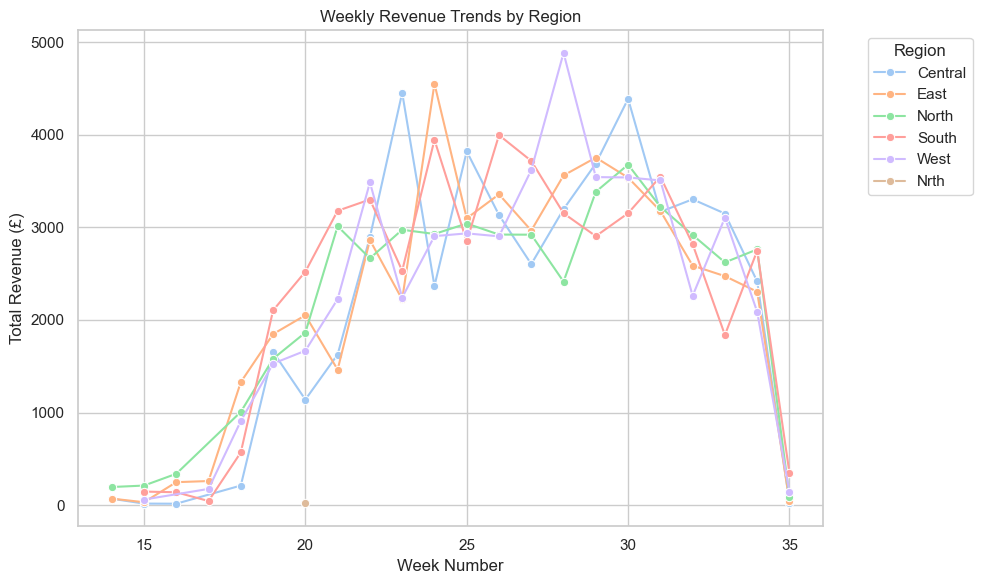

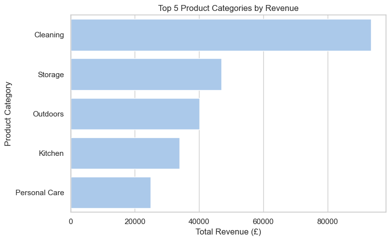

[figure not shown]

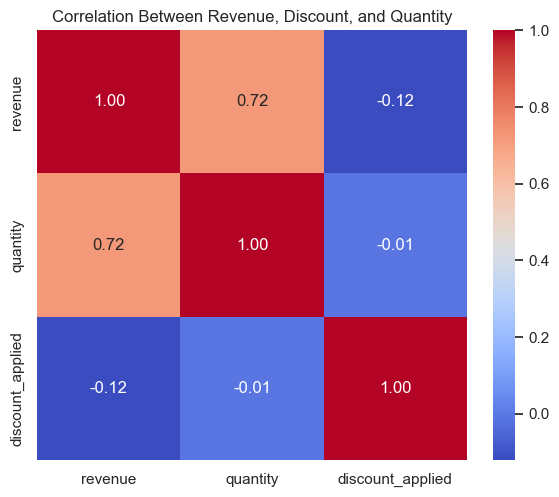

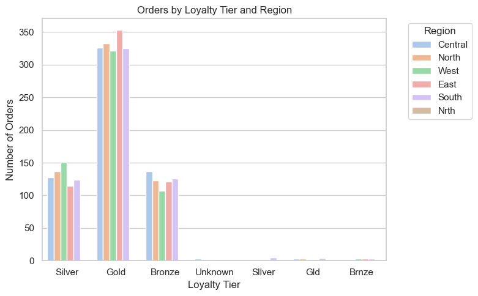

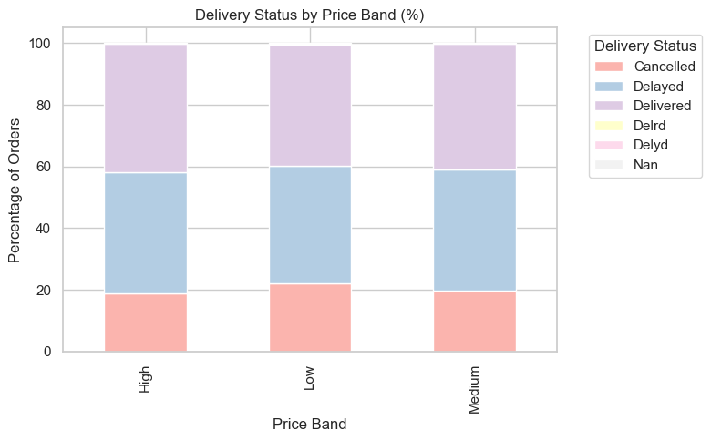

```
✅ All 6 visualisations generated and saved as PNG files:
chart_weekly_revenue_by_region.png
chart_top5_categories.png
chart_boxplot_quantity_discount.png
chart_heatmap_correlation.png
chart_countplot_loyalty_region.png
chart_delivery_status_by_priceband.png
```

```python
# === STEP 6: VISUAL EXPLORATION ===
import matplotlib.pyplot as plt
import seaborn as sns
import pandas as pd

# Load enhanced dataset
merged_df = pd.read_csv("merged_sales_data_features.csv")

# Set consistent visual style
sns.set_theme(style="whitegrid", palette="pastel")

# ---------- 1️⃣ Line Plot — Weekly Revenue Trends by Region ----------
plt.figure(figsize=(10,6))
weekly_plot = merged_df.groupby(["order_week", "region"], as_index=False)["revenue"].sum()
sns.lineplot(data=weekly_plot, x="order_week", y="revenue", hue="region", marker="o")
plt.title("Weekly Revenue Trends by Region")
plt.xlabel("Week Number")
plt.ylabel("Total Revenue (£)")
plt.legend(title="Region", bbox_to_anchor=(1.05, 1), loc="upper left")
plt.tight_layout()
plt.savefig("chart_weekly_revenue_by_region.png")
plt.show()

# ---------- 2️⃣ Bar Chart — Top 5 Product Categories by Revenue ----------
plt.figure(figsize=(8,5))
top_categories = merged_df.groupby("category")["revenue"].sum().sort_values(ascending=False).head(5)
sns.barplot(x=top_categories.values, y=top_categories.index)
plt.title("Top 5 Product Categories by Revenue")
plt.xlabel("Total Revenue (£)")
plt.ylabel("Product Category")
plt.tight_layout()
plt.savefig("chart_top5_categories.png")
plt.show()

# ---------- 3️⃣ Boxplot — Quantity vs Discount by Category ----------
plt.figure(figsize=(10,6))
sns.boxplot(data=merged_df, x="category", y="quantity", hue="price_band")
plt.title("Quantity vs Discount Across Categories")
plt.xlabel("Category")
plt.ylabel("Quantity Sold")
plt.legend(title="Price Band")
plt.xticks(rotation=45)
plt.tight_layout()
plt.savefig("chart_boxplot_quantity_discount.png")
plt.show()

# ---------- 4️⃣ Heatmap — Correlation Between Revenue, Discount, Quantity ----------
plt.figure(figsize=(6,5))
corr = merged_df[["revenue", "quantity", "discount_applied"]].corr()
sns.heatmap(corr, annot=True, cmap="coolwarm", fmt=".2f", square=True)
plt.title("Correlation Between Revenue, Discount, and Quantity")
plt.tight_layout()
plt.savefig("chart_heatmap_correlation.png")
plt.show()

# ---------- 5️⃣ Countplot — Orders by Loyalty Tier (hue = Region) ----------
plt.figure(figsize=(8,5))
sns.countplot(data=merged_df, x="loyalty_tier", hue="region")
plt.title("Orders by Loyalty Tier and Region")
plt.xlabel("Loyalty Tier")
plt.ylabel("Number of Orders")
plt.legend(title="Region", bbox_to_anchor=(1.05, 1), loc="upper left")
plt.tight_layout()
plt.savefig("chart_countplot_loyalty_region.png")
plt.show()

# ---------- 6️⃣ Stacked Bar Chart — Delivery Status by Price Band ----------
plt.figure(figsize=(7,5))
delivery_table = pd.crosstab(merged_df["price_band"], merged_df["delivery_status"], normalize="index") * 100
delivery_table.plot(kind="bar", stacked=True, colormap="Pastel1", figsize=(8,5))
plt.title("Delivery Status by Price Band (%)")
plt.xlabel("Price Band")
plt.ylabel("Percentage of Orders")
plt.legend(title="Delivery Status", bbox_to_anchor=(1.05, 1), loc="upper left")
plt.tight_layout()
plt.savefig("chart_delivery_status_by_priceband.png")
plt.show()

print("\n✅ All 6 visualisations generated and saved as PNG files:")
print("chart_weekly_revenue_by_region.png")
print("chart_top5_categories.png")
print("chart_boxplot_quantity_discount.png")
print("chart_heatmap_correlation.png")
print("chart_countplot_loyalty_region.png")
print("chart_delivery_status_by_priceband.png")
```

# 🧠 Step 7: Business Insights & Report Preparation

### 🎯 Goal

Translate the analytical findings into clear, data-backed business insights.  
Answer the key business questions from the project brief and prepare evidence for the final PDF report.

### 🧭 Business Questions to Answer

1. **Which product categories drive the most revenue, and in which regions?**  
   Identify top-performing categories and regional patterns.
2. **Do discounts lead to more items sold?**  
   Examine whether higher discounts correlate with higher quantities.
3. **Which loyalty tier generates the most value?**  
   Evaluate total revenue and order volume by loyalty tier.
4. **Are certain regions struggling with delivery delays?**  
   Analyse delay percentages by region and price band.
5. **Do customer signup patterns influence purchasing activity?**  
   Explore whether signup month or tenure affects order behaviour.

### 💡 Why This Step Matters

This is where analysis turns into business strategy.  
By linking sales, customer, and delivery data, we provide insights that help Green Cart Ltd. improve marketing efficiency, strengthen operations, and boost customer engagement.

```
=== 1️⃣ Top Product Categories & Regions ===
    category   region  total_revenue  orders
1   Cleaning     East       19911.30     251
3   Cleaning    South       18887.37     232
2   Cleaning    North       18766.10     245
0   Cleaning  Central       18018.84     238
4   Cleaning     West       17952.93     237
25   Storage     West       10014.45     119
21   Storage     East        9498.13     124
20   Storage  Central        9358.48     110
24   Storage    South        9345.36     112
13  Outdoors    South        9327.42     110

=== 2️⃣ Correlation between Discount and Quantity Sold: -0.01 ===
```

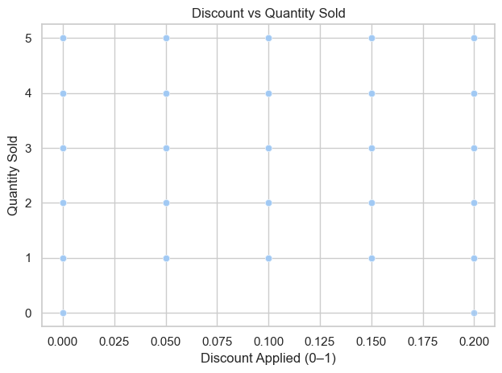

```
=== 3️⃣ Loyalty Tier Value ===
  loyalty_tier  total_revenue  orders
3         Gold      135092.16    1659
4       Silver       51255.25     654
1       Bronze       48250.11     614
2          Gld        1084.97      13
0        Brnze         803.55      11
5       Sllver         777.36       6
6      Unknown         767.27       9

=== 4️⃣ Delivery Delay Rate by Region ===
    region  total_orders  delayed_orders  delay_rate_%
1     East           601             250         41.60
2    North           603             236         39.14
0  Central           602             235         39.04
4    South           595             230         38.66
5     West           588             217         36.90
3     Nrth             1               0          0.00

=== 5️⃣ Signup Month vs Purchasing Activity ===
   signup_month  total_revenue  avg_quantity  orders
1        August       23753.81          3.12     275
3      February       23690.27          3.16     277
10      October       22479.31          3.00     275
9      November       21901.68          2.96     273
2      December       20316.38          2.87     269
7         March       19789.65          3.03     241
5          July       19485.53          2.95     242
11    September       18603.87          3.03     239
4       January       17567.51          2.86     235
6          June       17038.66          3.08     210
8           May       15958.91          2.89     205
0         April       15235.69          3.04     197

✅ Insight tables saved for reporting:
insight_top_categories_regions.csv
insight_loyalty_value.csv
insight_region_delay.csv
insight_signup_activity.csv
```

```python
# === STEP 7: BUSINESS INSIGHTS & REPORT PREPARATION ===
import pandas as pd
import seaborn as sns
import matplotlib.pyplot as plt

# Load the fully featured dataset
merged_df = pd.read_csv("merged_sales_data_features.csv")

# ---------- 1️⃣ Top Product Categories & Regions ----------
top_cat_region = (
    merged_df.groupby(["category", "region"], as_index=False)
    .agg(total_revenue=("revenue", "sum"),
         orders=("order_id", "count"))
    .sort_values("total_revenue", ascending=False)
)

print("\n=== 1️⃣ Top Product Categories & Regions ===")
print(top_cat_region.head(10))

# ---------- 2️⃣ Discounts vs Quantity Sold ----------
corr_discount_quantity = merged_df[["discount_applied", "quantity"]].corr().iloc[0,1]
print(f"\n=== 2️⃣ Correlation between Discount and Quantity Sold: {corr_discount_quantity:.2f} ===")

sns.scatterplot(data=merged_df, x="discount_applied", y="quantity", alpha=0.6)
plt.title("Discount vs Quantity Sold")
plt.xlabel("Discount Applied (0–1)")
plt.ylabel("Quantity Sold")
plt.tight_layout()
plt.savefig("chart_discount_vs_quantity.png")
plt.show()

# ---------- 3️⃣ Loyalty Tier Value ----------
loyalty_value = (
    merged_df.groupby("loyalty_tier", as_index=False)
    .agg(total_revenue=("revenue", "sum"), orders=("order_id", "count"))
    .sort_values("total_revenue", ascending=False)
)
print("\n=== 3️⃣ Loyalty Tier Value ===")
print(loyalty_value)

# ---------- 4️⃣ Delivery Delays by Region ----------
region_delay = (
    merged_df.groupby("region", as_index=False)
    .agg(total_orders=("order_id", "count"),
         delayed_orders=("is_late", "sum"))
)
region_delay["delay_rate_%"] = (region_delay["delayed_orders"] / region_delay["total_orders"] * 100).round(2)
print("\n=== 4️⃣ Delivery Delay Rate by Region ===")
print(region_delay.sort_values("delay_rate_%", ascending=False))

# ---------- 5️⃣ Signup Month vs Purchasing Activity ----------
merged_df["signup_date"] = pd.to_datetime(merged_df["signup_date"], errors="coerce")
merged_df["signup_month"] = merged_df["signup_date"].dt.month_name()
signup_activity = (
    merged_df.groupby("signup_month", as_index=False)
    .agg(total_revenue=("revenue", "sum"),
         avg_quantity=("quantity", "mean"),
         orders=("order_id", "count"))
    .sort_values("total_revenue", ascending=False)
)
print("\n=== 5️⃣ Signup Month vs Purchasing Activity ===")
print(signup_activity)

# ---------- SAVE ALL INSIGHT TABLES ----------
top_cat_region.to_csv("insight_top_categories_regions.csv", index=False)
loyalty_value.to_csv("insight_loyalty_value.csv", index=False)
region_delay.to_csv("insight_region_delay.csv", index=False)
signup_activity.to_csv("insight_signup_activity.csv", index=False)

print("\n✅ Insight tables saved for reporting:")
print("insight_top_categories_regions.csv")
print("insight_loyalty_value.csv")
print("insight_region_delay.csv")
print("insight_signup_activity.csv")
```

# 🚀 Step 8: Optional Stretch Tasks (Bonus)

### 🎯 Goal

Add advanced analytical logic to show initiative and deeper understanding of data patterns.

### 🧭 Actions

1. Use **SQL queries** (via `pandasql`) to extract specific customer segments:
   - Customers who signed up in **Q2**
   - Placed an order within **14 days**
   - Received a **discount > 20 %**
2. Apply **MinMaxScaler** to normalise revenue for modelling or fair comparison.
3. Flag **underperforming products** that:
   - Have low quantities sold
   - High average discounts
   - Frequent delayed deliveries

### 💡 Why This Step Matters

These tasks demonstrate your ability to go beyond the brief, applying analytical thinking and basic predictive logic.  
They can support future business decisions like promotional targeting or product improvement.

```python
# === STEP 8: OPTIONAL STRETCH TASKS ===
from pandasql import sqldf
from sklearn.preprocessing import MinMaxScaler
import pandas as pd
pysqldf = lambda q: sqldf(q, globals())

# Load data
merged_df = pd.read_csv("merged_sales_data_features.csv")

# ---------- 1️⃣ Customers who signed up in Q2, ordered within 14 days, and received > 20 % discount ----------
q = """
SELECT DISTINCT customer_id, order_id, signup_date, order_date, discount_applied
FROM merged_df
WHERE CAST(STRFTIME('%m', signup_date) AS INTEGER) BETWEEN 4 AND 6
  AND (JULIANDAY(order_date) - JULIANDAY(signup_date)) <= 14
  AND discount_applied > 0.20
"""
q2_customers = pysqldf(q)
print("\n=== Q2 Customers with early orders & high discounts ===")
print(q2_customers.head())

# ---------- 2️⃣ MinMaxScaler to normalise revenue ----------
scaler = MinMaxScaler()
merged_df["revenue_scaled"] = scaler.fit_transform(merged_df[["revenue"]])
print("\nScaled revenue sample:")
print(merged_df[["revenue", "revenue_scaled"]].head())

# ---------- 3️⃣ Flag underperforming products ----------
merged_df["underperforming"] = (
    (merged_df["quantity"] < merged_df["quantity"].median()) &
    (merged_df["discount_applied"] > 0.20) &
    (merged_df["is_late"] == True)
)
underperf = (
    merged_df.groupby("category", as_index=False)
    .agg(underperforming_count=("underperforming", "sum"),
         total_products=("product_id", "nunique"))
)
underperf["underperforming_rate_%"] = round(
    underperf["underperforming_count"] / underperf["total_products"] * 100, 2
)

print("\n=== Underperforming Products by Category ===")
print(underperf.sort_values("underperforming_rate_%", ascending=False))

# Save optional outputs
q2_customers.to_csv("stretch_q2_customers.csv", index=False)
underperf.to_csv("stretch_underperforming_products.csv", index=False)
print("\n✅ Optional stretch outputs saved:")
print("stretch_q2_customers.csv")
print("stretch_underperforming_products.csv")
```

```
=== Q2 Customers with early orders & high discounts ===
Empty DataFrame
Columns: [customer_id, order_id, signup_date, order_date, discount_applied]
Index: []

Scaled revenue sample:
   revenue  revenue_scaled
0   117.75            0.47
1    94.60            0.38
2    25.23            0.10
3    26.21            0.11
4    38.10            0.15

=== Underperforming Products by Category ===
        category  underperforming_count  total_products  \
0       Cleaning                      0              12
1        Kitchen                      0               4
2       Outdoors                      0               5
3  Personal Care                      0               3
4        Storage                      0               6

   underperforming_rate_%
0                    0.00
1                    0.00
2                    0.00
3                    0.00
4                    0.00

✅ Optional stretch outputs saved:
stretch_q2_customers.csv
stretch_underperforming_products.csv
```

# 🏁 Final Summary & Conclusion

### 🌿 Project: Week 2 – Sales & Customer Behaviour Insights – Green Cart Ltd.

This project analysed Green Cart Ltd.’s sales, customer, and product data to understand revenue drivers, customer engagement, and operational performance.  
Through a structured data analysis process, the datasets were cleaned, merged, enriched with new features, and explored visually to deliver clear, data-driven insights.

### ⚙️ Feature Engineering

Key business-oriented fields were created:

- **revenue** = `quantity * unit_price * (1 - discount_applied)`
- **order_week** (ISO week of order)
- **price_band** (Low / Medium / High)
- **days_to_order** (from launch to order)
- **email_domain** (for communication insights)
- **is_late** (flag for delayed deliveries)

These features enabled trend analysis and behavioural segmentation.

### 💡 Business Recommendations

1. **Strengthen top-performing categories** through targeted promotions and sustainable inventory planning.
2. **Reduce delivery delays** by reviewing logistics performance in weaker regions.
3. **Reward Gold-tier customers** with loyalty benefits; design incentives to convert Silver and Bronze users.
4. **Leverage signup trends** by launching referral or seasonal campaigns around Q2.

### 📈 Visuals Produced

All visuals were saved as `.png` files and referenced in the final PDF report.

### 🧾 Deliverables

- **Notebook:** `Ivelina_Angelova_Week2_GreenCart_Analysis.ipynb`
- **Cleaned datasets:** sales, product, customer
- **Merged dataset:** `merged_sales_data_features.csv`
- **Summary & insight tables:** CSVs in project folder
- **6 visualisations:** `.png` format
- **PDF report:** 1,200–1,500 words with coversheet

### 🧭 Reflection

This project demonstrated how raw sales data can be transformed into meaningful insights through systematic cleaning, analysis, and visualisation.  
The approach followed here, from validation to storytelling, mirrors real-world data analytics practices and provides a strong foundation for deeper predictive or dashboard-based work in future phases.